# Обработка текста

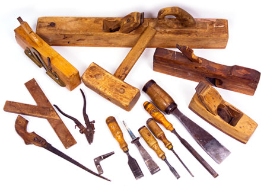

Кирилл Корняков (Intel, ННГУ)  
Март 2018

# Содержание

1. Текстовые редакторы
2. Возможности современных редакторов (на примере Sublime Text)
3. Регулярные выражения

# Два совета

1. Освойте слепой метод печати
   - Вы начинаете работать "со скоростью мысли"
   - Мозгу не нужно переключаться, вы фокусируетесь на задаче
   - Это полезно для глаз
   - Тренажеры: [русский](http://vse10.ru), [английский](http://www.ratatype.com)
2. Избегайте использования мыши
   - Экономия до 30% рабочего времени
   - Освойте клавиатурные комбинации ("горячие клавиши")

# Текстовые редакторы

> Используйте один текстовый редактор, но по максимуму.

Дэвид Хант, Андрю Томас "Программист-прагматик"

> Найдите идеальный для себя редактор и досконально изучите его.

Нил Форд, "Продуктивный программист"

# Важные свойства редакторов

- Кросс-платформенность
- Настраиваемость
  - Шрифты, оформление, клавиатурные комбинации
- Расширяемость
  - Новые языки программирования и форматы файлов
- Программируемость
  - Программируемость сложных операций (макросы, сценарии)
- Скорость работы

# Learning Curves

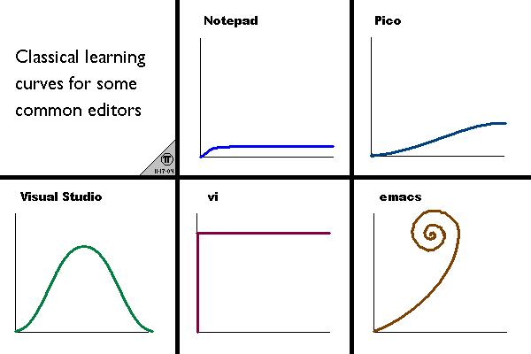

# Vim

[figure not shown]

- Vim — свободный текстовый редактор, созданный на базе vi.
- Один из культовых редакторов.
- Один из мощнейших редакторов, с полной свободой настройки и автоматизации.
- Имеет огромное количество расширений (более 3000).
- Используется практически в любых проектах.
- Официальный сайт проекта: http://www.vim.org.

# Vim UI

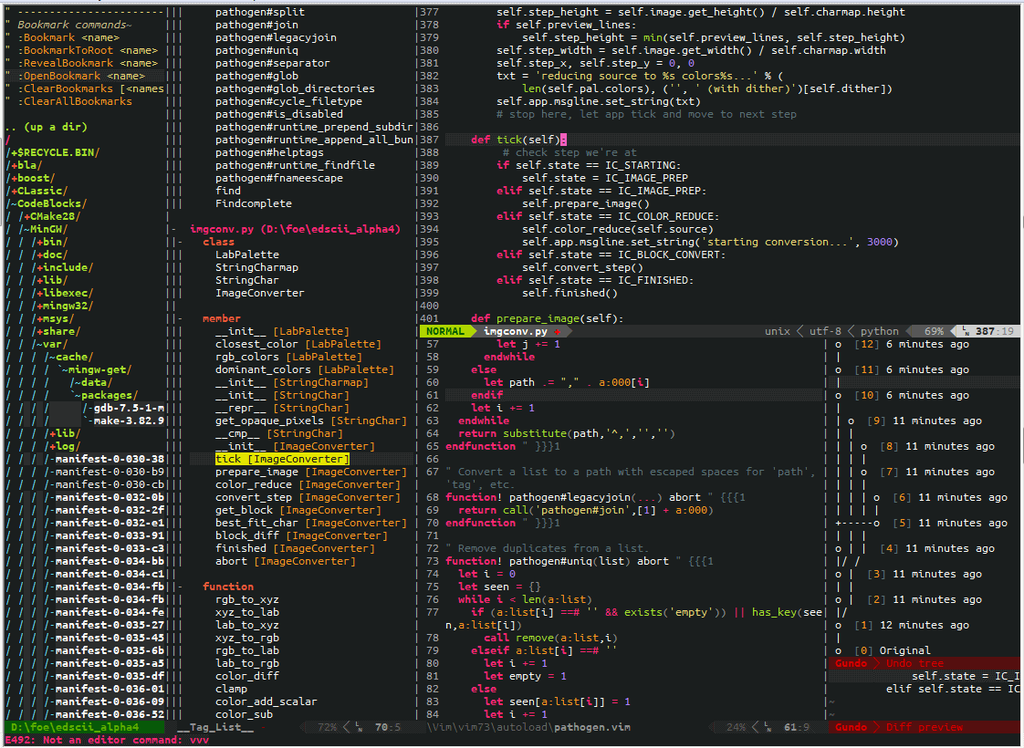

# Vim Cheatsheet

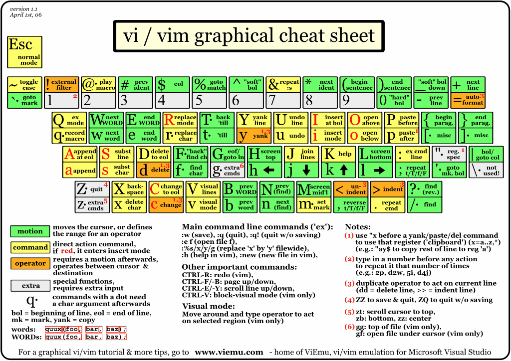

# Vim examples

- `5D`, `Y5p` — удалить/повторить строку 5 раз
- `/^joe` — найти все строки, начинающиеся с joe
- `:g!/REGEXP/d` — удалить все строки, не содержащие REGEXP
- `:%norm jdd` — удалить каждую вторую строку
- `ci(`, `ci[` — удалить содержимое внутри скобок
- `guu`, `gUU` — перевести всю строку в нижний/верхний регистр

Настройки Vim

- `:history` — показать историю команд
- `:set number` — показать номера строк

# Emacs

[figure not shown]

- Emacs — семейство расширяемых многофункциональных текстовых редакторов.
- Второй культовый редактор.
- Возможно еще более мощный редактор, чем Vim (Emacs as an OS).
- Имеет более 2000 встроенных команд, позволяет комбинировать их в макросы.
- Официальный сайт проекта http://www.gnu.org/software/emacs.

# Emacs UI

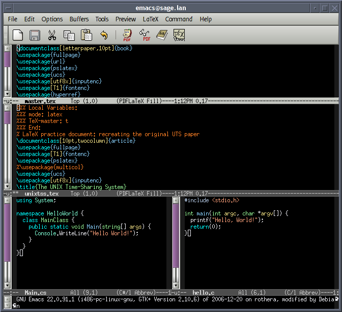

# Идеология Emacs

- "Всё в одном"
  - Функциональность: базовая, основной режим, дополнительные режимы
- Расширяемость
  - Программируется на Elisp, имеются пакеты расширений, клавиатурные комбинации
- Настраиваемость под пользователя
  - Elisp-переменные, определение функций, создание hook'ов
- Документированность
  - Подробная документация, вплоть до функций и переменных

# Sublime Text

[figure not shown]

- Sublime Text — кроссплатформенный редактор текста и кода.
- Имеет Python API, существует большое количество раширений.
- Не является свободным, однако почти все расширения открыты.
- Официальный сайт проекта http://www.sublimetext.com.

# Sublime Text UI

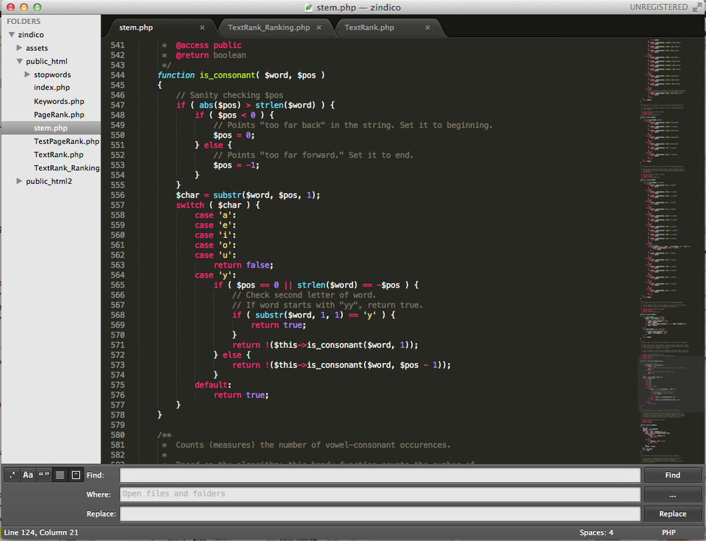

# Sublime Text: Горячие клавиши

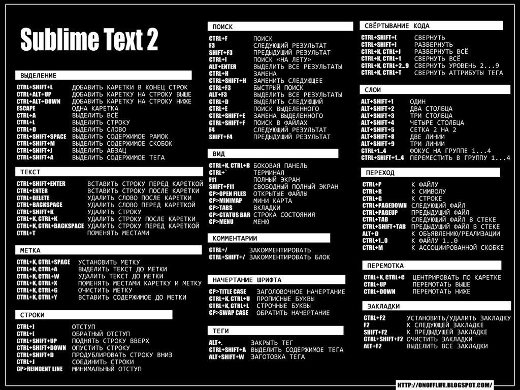

# Содержание

1. Текстовые редакторы
2. Возможности современных редакторов (на примере Sublime)
3. Регулярные выражения

# Навигация

1. По файлам
   - Перебор закладок
   - Боковая панель
   - **Go to anything**
2. Внутри файлов
   - Хождение по словам, строкам, экрану
   - Переход на строку
   - Переход между скобками
   - **Go to symbol**

# Выделение

1. Слов, Строк
2. Абзацев
3. Выражений внутри скобок
4. Всех вхождений слова => Поиск

# Поиск

1. Простой поиск
   - **Multiple cursor**
   - **Регулярные выражения**
2. Инкрементальный
3. Быстрый

# Редактирование

1. Комментирование
2. Перестановка двух символов
3. Удаление: слов, строк, окончаний строк
4. Манипуляции со строками
   - Дублирование, переупорядочение, сортировка
   - Слияние и автоматический перенос
5. Редактирование нескольких строк и прямоугольных регионов

# Продвинутые возможности

1. Package Control
2. Snippets
3. Vintage Mode
4. Custom Builds
5. Projects

# Содержание

1. Текстовые редакторы
2. Возможности современных редакторов (на примере Sublime)
3. Регулярные выражения

# Регулярные выражения

> **Регулярные выражения** (англ. regular expressions) — формальный язык поиска и осуществления манипуляций с подстроками в тексте, основанный на использовании метасимволов (англ. wildcard characters).

> По сути это строка-образец (англ. pattern, по-русски её часто называют «шаблоном», «маской»), состоящая из символов и метасимволов, и задающая правило поиска.

Wikipedia

Метасимволы: `[ ] \ / ^ $ . | ? * + ( ) { }`

# Примеры регулярных выражений

- `polynomial`
- `3\.1415926`
- `static`
- `static .*(.*;`
- `^class`
- `[0-9]{6}`

# Синтаксис

- Обычные строки обозначают сами себя
- `.` — может быть использована вместо любого символа
- `\` — экранирует метасимволы (`/` иногда используется как разделитель)
- `( )` — группировка, указывает приоритет операций
- `[ ]` — обозначает символьный класс (`[abc], [0123456789], [а-я], [0-9]`)
- `^ $` — указывают на начало и конец строки
- `? * + { }` — указывают число повторений

# Примеры регулярных выражений

Что ищут эти выражения, и какие они имеют недостатки?

- `[a-z]+@[a-z]+\.com`
- `([0-9]{4}\ ){4}`
- `\b\d{1,3}\.\d{1,3}\.\d{1,3}\.\d{1,3}\b`
- `[-+]?[0-9]+\.[0-9]+`
- Lookaround
  - lookahead: `[0-9]{2}(?=\ years)`
  - lookbehind: `(?<=[0-9]{4}\ \()[0-9]{2}`

# Ключевые моменты

1. Освойте слепой метод набора текста
2. Выберите себе текстовый редактор, и изучите его досконально
   - Попробуйте программировать в текстовом редакторе
3. Распечатайте шпаргалку с горячими клавишами
   - Постарайтесь не использовать мышь для навигации, выделения
4. Освойте регулярные выражения
   - Используйте их для поиска и замены, пакетной обработки файлов

# Контрольные вопросы

1. Важные свойства текстовых редакторов.
2. Определение и синтаксис регулярных выражений.
3. Предложите регулярное выражение для поиска:
   - Поиска дат в формате `2013-09-18` или `14-01-01`
   - IP-адресов
   - номеров банковских карт
   - HEX-представления чисел типа `int`
   - Имен всех классов в вашем С++ проекте
4. Как будет выглядет команда в Vim для:
   - Отсортировать файл и удалить дубликаты
   - Перевести слово под курсором в верхний регистр
   - Перевести всю строку в верхний регистр (капитализация)
   - Создать 10 копий текущей строки
   - Удалить все "висячие пробелы" (trailing whitespaces)
   - Удалить все пустые строки в файле
   - Удалить все строки, содержащие слово `WARNING`
   - Удалить каждую вторую строку
   - Удалить текст в рамках текущих скобок или кавычек

# Спасибо!

Вопросы?